# Hearing

[back to Home page |](https://github.com/huiwen-goy/C2-multidomain) [back to Analyses page |](https://huiwen-goy.github.io/C2-multidomain/C2-11Analyses.html) [Data quality |](https://huiwen-goy.github.io/C2-multidomain/C2-1Quality.html)

[Demographics |](https://huiwen-goy.github.io/C2-multidomain/C2-2Demographic.html) [Physical health |](https://huiwen-goy.github.io/C2-multidomain/C2-3Physical.html) [Hearing |](https://huiwen-goy.github.io/C2-multidomain/C2-4Hearing.html) [Cognition |](https://huiwen-goy.github.io/C2-multidomain/C2-5Cognition.html) [Mobility and balance |](https://huiwen-goy.github.io/C2-multidomain/C2-6Mobility.html) [Quality of life |](https://huiwen-goy.github.io/C2-multidomain/C2-7QoL.html) [Mental health |](https://huiwen-goy.github.io/C2-multidomain/C2-8Mental.html) [Social |](https://huiwen-goy.github.io/C2-multidomain/C2-9Social.html) [Views |](https://huiwen-goy.github.io/C2-multidomain/C2-10Views.html)

# Audiograms

84.6% of 527 participants have a complete audiogram available.

PTA4 = sum of thresholds at (0.5 + 1 + 2 + 4) kHz / 4 (note that 3 kHz thresholds were not measured).

Hearing asymmetry = absolute value of PTA4 difference between ears

Subjective hearing loss = ‘Yes’ to “Do you have a hearing loss?”

Hearing difficulty = ‘Poor’ or ‘Fair’ to “How would you rate your hearing…”

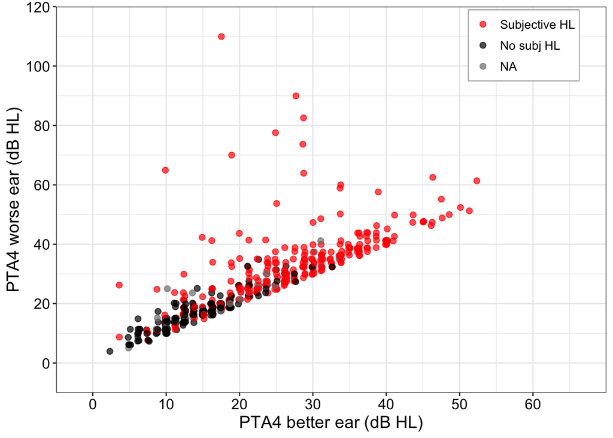

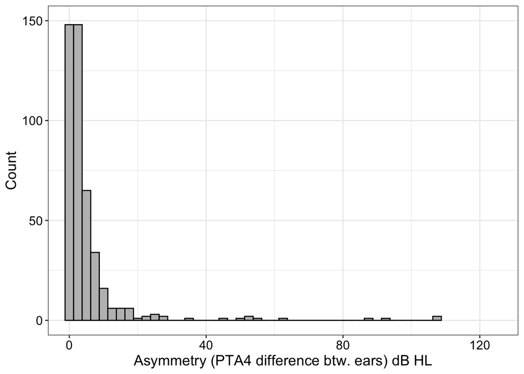

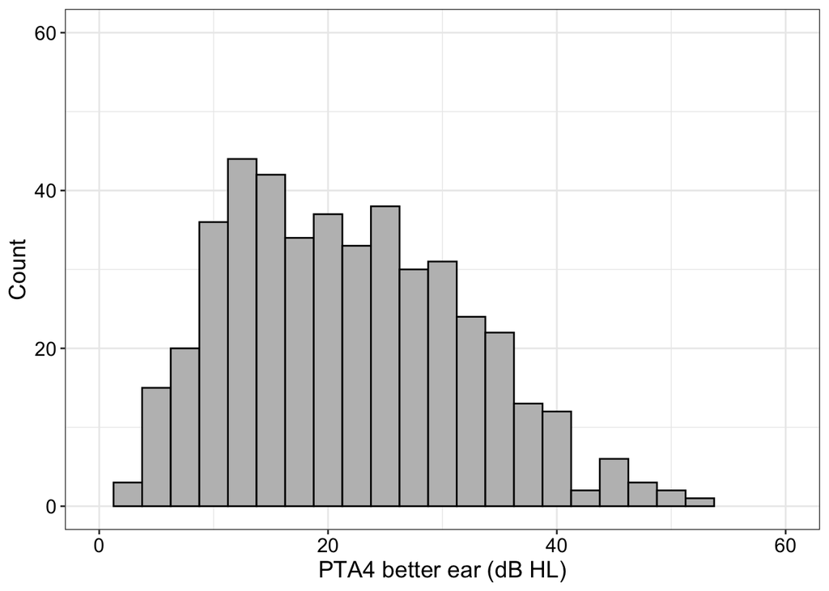

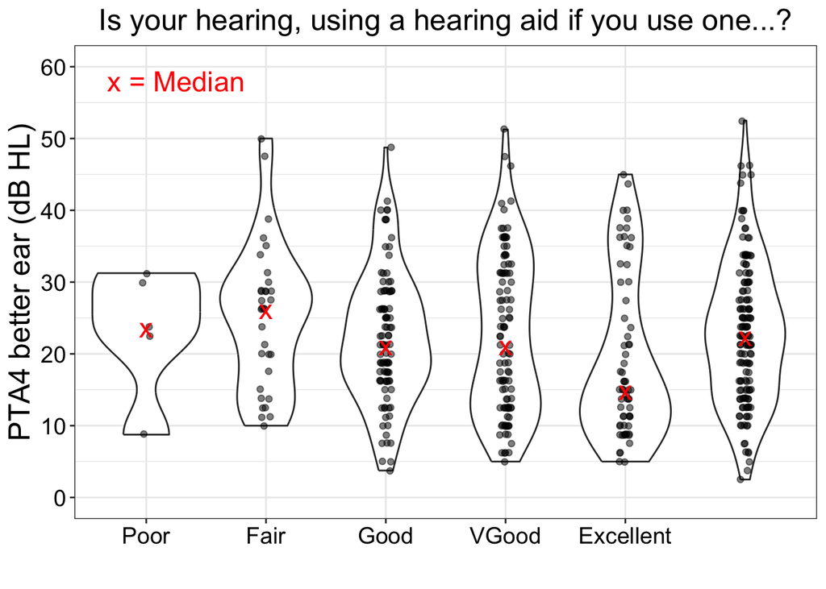

# IOI-HA

back to top

Only those who said that they use “Hearing aids” (n = 103) in the Subjective Hearing section are presented with this scale.

Responses are discrete options, ranging from 1 (poorer outcome) to 5 (better outcome). The overall score is an average of responses (Cox & Alexander, 2002).

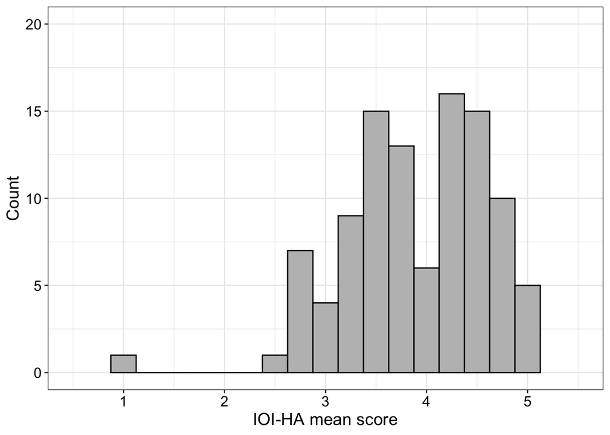

# Tinnitus

back to top

Source: Canadian Health Measures Survey 2014-2015 (cycle 4).

```
##     Tinnitus    %
## 1        Yes 49.1
## 2         No 44.8
## 3 Don't know  0.0
## 4       <NA>  6.1
```

```
##   When experienced Count
## 1          Last 7d   172
## 2       8d to 1 mo    15
## 3           1-6 mo    25
## 4          6-12 mo    14
## 5            1 yr+    33
## 6             <NA>     0
```

```
##   Bother    %
## 1    Yes 28.6
## 2     No 71.4
## 3   <NA>  0.0
```

```
##   More than 5min    %
## 1       All/Most 37.1
## 2          A lot 12.7
## 3           Some 21.6
## 4  Not past year 10.0
## 5          Never 13.1
## 6           <NA>  5.4
```

```
##         Annoy    %
## 1    Severely  5.2
## 2  Moderately 21.3
## 3    Slightly 42.7
## 4  Not at all 18.0
## 5 Do not know  0.5
## 6        <NA> 12.3
```

# 15i-SSQ

back to top

Responses are a continuous sliding scale from 0 (“Not at all”) to 10 (“Perfectly”). “Not Applicable” is a valid response option.  
Responses are averaged within 3 clusters of questions to form scores for each subscale, with a higher score indicating better hearing.

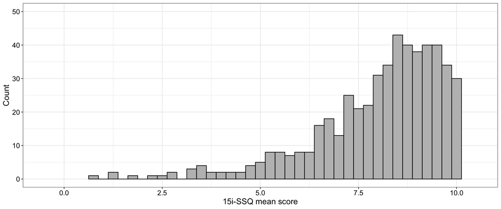

[figure not shown]

# Social Isolation Measure

back to top

Responses are discrete options, ranging in steps of one from 0 (Completely Disagree) to 10 (Completely Agree).  
The overall score is an average of responses, with a lower score indicating less isolation. No items are reverse-coded.

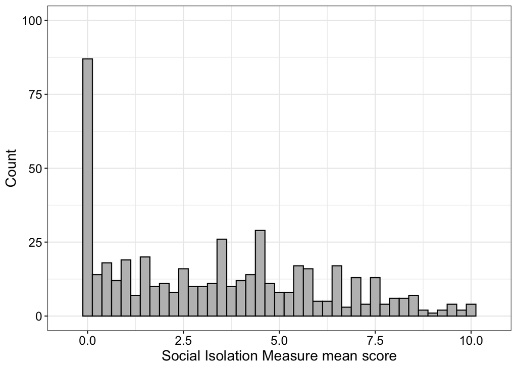

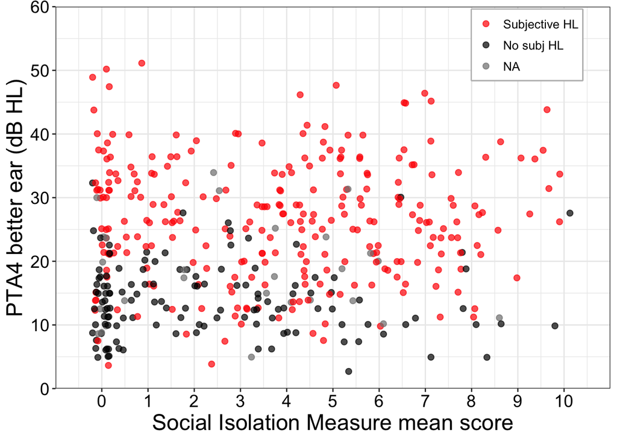

# EmoCheQ

back to top

Responses are 5 discrete options, ranging from 1 (Strongly Disagree) to 5 (Strongly Agree). The overall score is an average of responses, with lower numbers indicating better emotion perception. No items are reverse-coded.

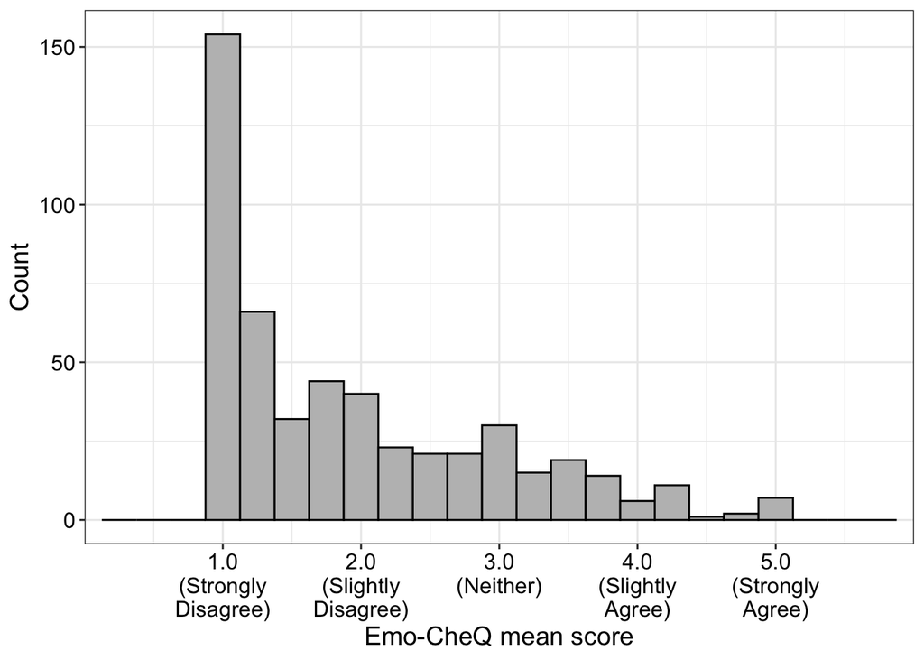

# HHIE-S

back to top

Responses are 3 discrete options, Yes / Sometimes / No. Subscores are sums of responses in each cluster of questions, with a higher score indicating a poorer outcome.

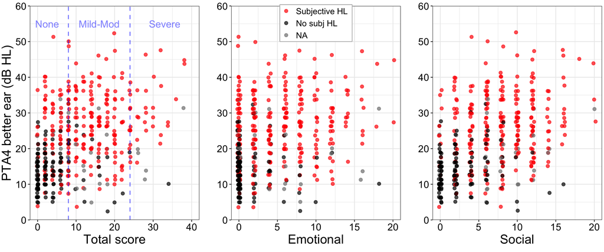

# Correlation between measures

back to top

Note that “subjective hearing loss” and “hearing difficulty” are binary measures, whereas the rest are continuous.

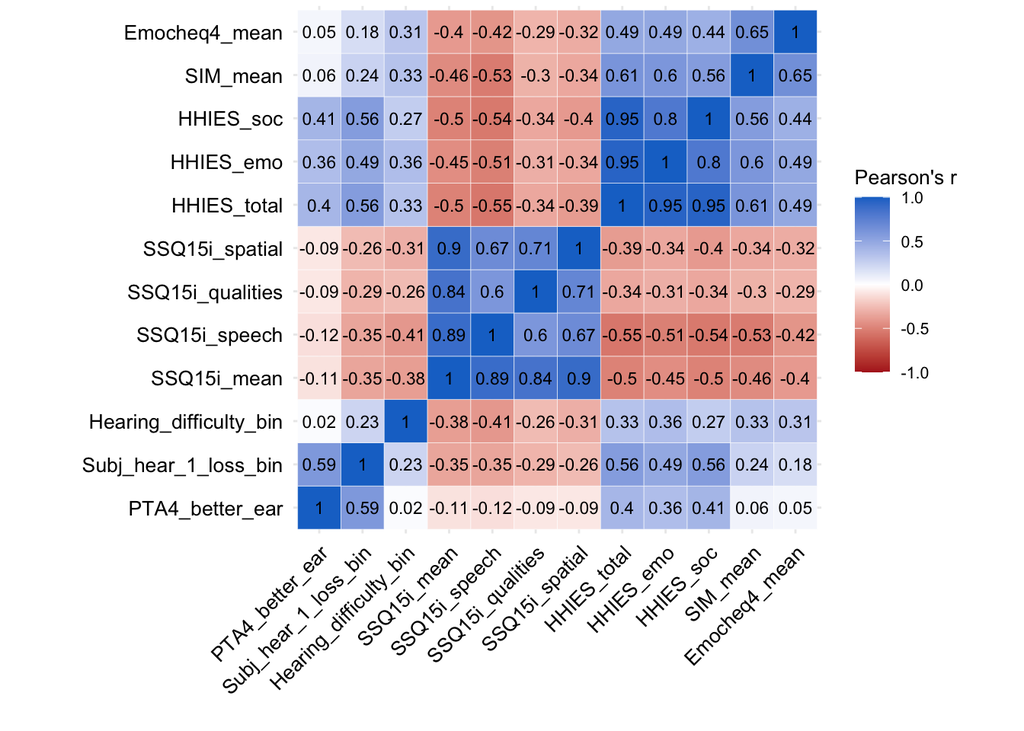

# Other variables available

back to top

- Types of hearing assistive devices used (almost all hearing aids)
- Date of last hearing checkup
- Number of years using hearing aids
- Hearing-related items on the CRSQ such as “I have had diﬃculty hearing conversations in noisy places”